# Assignment 15: Writing a function - Conditional Statement

*How to do it?*:

- Open the Rmarkdown file of this assignment (link) in Rstudio.
- Right under each **question**, insert a code chunk (you can use the hotkey `Ctrl + Alt + I` to add a code chunk) and code the solution for the question.
- `Knit` the rmarkdown file (hotkey: `Ctrl + Alt + K`) to export an html.
- Publish the html file to your Githiub Page.

*Submission*: Submit the link on Github of the assignment to Canvas

#### NOTICE: Question 7, 8 and 9 are optional.

1. Write a function to calculate the age of a person. Give an example to test your function.
- Input: a number, x, (year born)
- Output: Print out “You are r age”. Where r is the age of the person, i.e. 2020 - x.

Hint: [Similar Function](https://bryantstats.github.io/math421/gganimate/17_writing_functions.html#42)

```r
# Creating a function to calculate age based on birth year.
age <- function(x)
{
  r = 2023 - x
  print(paste0('You are ', r, ' age.'))
}
age(2002)
```

```
## [1] "You are 21 age."
```

2. Write the following function. Give an example to test your function.
- Input: a number
- Output: print out: “You input an even number!” if the number is event, or “You input an odd number!” otherwise.

Hint: [Similar Function](https://bryantstats.github.io/math421/gganimate/17_writing_functions.html#46)

```r
# Creating a function do determine wheter a number is odd or even. I'm sure there are many ways to create this function, but this was the first way that came to mind. An integer is divided by 2, and then the floor fuction is used to check if the number is a whole number. You could make this function better by implementing an if statement to handle the exception of when the user enters a value that is not an integer.

numType <- function(x)
{
  r = x/2
  ifelse(r != floor(r), "odd","even")
}

# Testing function.
numType(seq(1:10))
```

```
##  [1] "odd"  "even" "odd"  "even" "odd"  "even" "odd"  "even" "odd"  "even"
```

3. Write the following function. Give an example to test your function.
- Input: a numeric vector
- Output:
  - if the input vector has missing values: return the input vector with missing values replaced by mean
  - if the input vector has no missing value: return the same input vector

Hint: [Similar Function](https://bryantstats.github.io/math421/gganimate/17_writing_functions.html#50)

```r
# Creating a function to impute missing values with the mean. First, there is an if statement to determine whether the variable is numeric before imputation. This method will handle that exception.
mean_impute <- function(x)
{
  if(is.numeric(x))
  {
    # Find the mean of x
    mean_of_x <- mean(x, na.rm = TRUE)
    # Replace the missing by the mean
    library(tidyr)
    x <- replace_na(x, mean_of_x)
  }
  return(x)
}
```

```r
# Proving that this variable contains missing values. The variable `mag` represents the magnitude of tornados in the dataset. For this question, I'll be using the tornados.csv dataset source: https://www.kaggle.com/datasets/danbraswell/us-tornado-dataset-1950-2021

library(tidyverse)
df <- read_csv('tornados.csv')
sum(is.na(df$mag))
```

```
## [1] 756
```

```r
# Test the function on numeric data that contains missing values.
x1 <- mean_impute(df$mag)
sum(is.na(x1))
```

```
## [1] 0
```

4. Write the following function. Give an example to test your function.
- Input: a vector x
- Output: The vector x where the missing values replaced by the mean (if x is numeric) or the mode (if x is non-numeric). If x does not have missing value, return the same vector x.

Hint: Use If-statement to combine the function in Question 3 and [this function](https://bryantstats.github.io/math421/gganimate/17_writing_functions.html#49)

```r
# Creating a function to handle instances when the input is not numeric. This time I'll replace the missing values with the category that has occured the most.

mode_impute <- function(x)
{
  if(!is.numeric(x))
  {
    # Find the mode of x
    mode_of_x <- names(sort(-table(x)))[1]
    # Replace the missing by the mode
    library(tidyr)
    x <- replace_na(x, mode_of_x)
  }
  return(x)
}
```

```r
# Creating a function to handle missing values for either categorical or numeric.

impute_missing <- function(x)
{
  if(sum(is.na(x)) > 0)
  {
    if(!is.numeric(x))
    {
      mode_of_x <- names(sort(-table(x)))[1]
      library(tidyr)
      x <- replace_na(x, mode_of_x)
    }
    mean_of_x <- mean(x, na.rm = TRUE)
    library(tidyr)
    x <- replace_na(x, mean_of_x)
  }
  return(x)
}
```

```r
# Viewing the data frame.
df
```

```
## # A tibble: 68,693 × 27
##       om    yr    mo    dy date       time   tz        datetime_utc        st
##    <dbl> <dbl> <dbl> <dbl> <date>     <time> <chr>     <dttm>              <chr>
##  1   192  1950    10     1 1950-10-01 21:00  America/… 1950-10-02 03:00:00 OK
##  2   193  1950    10     9 1950-10-09 02:15  America/… 1950-10-09 08:15:00 NC
##  3   195  1950    11    20 1950-11-20 02:20  America/… 1950-11-20 08:20:00 KY
##  4   196  1950    11    20 1950-11-20 04:00  America/… 1950-11-20 10:00:00 KY
##  5   197  1950    11    20 1950-11-20 07:30  America/… 1950-11-20 13:30:00 MS
##  6   194  1950    11     4 1950-11-04 17:00  America/… 1950-11-04 23:00:00 PA
##  7   198  1950    12     2 1950-12-02 15:00  America/… 1950-12-02 21:00:00 IL
##  8   199  1950    12     2 1950-12-02 16:00  America/… 1950-12-02 22:00:00 IL
##  9   200  1950    12     2 1950-12-02 16:25  America/… 1950-12-02 22:25:00 AR
## 10   201  1950    12     2 1950-12-02 17:30  America/… 1950-12-02 23:30:00 IL
## # ℹ 68,683 more rows
## # ℹ 18 more variables: stf <dbl>, mag <dbl>, inj <dbl>, fat <dbl>, loss <dbl>,
## #   slat <dbl>, slon <dbl>, elat <dbl>, elon <dbl>, len <dbl>, wid <dbl>,
## #   ns <dbl>, sn <dbl>, f1 <dbl>, f2 <dbl>, f3 <dbl>, f4 <dbl>, fc <lgl>
```

```r
# Checking for missing values.
colSums(is.na(df))
```

```
##           om           yr           mo           dy         date         time
##            0            0            0            0            0            0
##           tz datetime_utc           st          stf          mag          inj
##            0            0            0            0          756            0
##          fat         loss         slat         slon         elat         elon
##            0        27170            0            0            0            0
##          len          wid           ns           sn           f1           f2
##            0            0            0            0            0            0
##           f3           f4           fc
##            0            0            0
```

```r
# Testing the function on data. This time I'll use the variable `loss`.
l1 <- impute_missing(df$loss)

sum(is.na(l1))
```

```
## [1] 0
```

5. Write the following function. Give examples to test your function.
- Input: A data frame of two variables x and y
- Output:
  - A boxplot of x by y if x is numeric and y is non-numeric
  - A boxplot of y by x if y is numeric and x is non-numeric
  - print out ‘This function cannot visualize your data’ otherwise

Hint:

- [Similar Function](https://bryantstats.github.io/math421/gganimate/17_writing_functions.html#53)
- You can refer to this slide to plot a boxplot: https://bryantstats.github.io/math421/slides/6_viz.html#36

```r
# First, Let's make a data frame to test the function.
df <- data.frame(
  Salary = c(450, 1020, 842, 945, 1208, 670, 480, 720),
  Hours = c("Part-Time","Full-Time","Part-Time", "Full-Time", "Full-Time","Part-Time","Part-Time","Part-Time")
)
df
```

```
##   Salary     Hours
## 1    450 Part-Time
## 2   1020 Full-Time
## 3    842 Part-Time
## 4    945 Full-Time
## 5   1208 Full-Time
## 6    670 Part-Time
## 7    480 Part-Time
## 8    720 Part-Time
```

```r
# Creating the function to create box plots for dataframes with two variables. This done using 'if' statements to handle each case.

viz <- function(d)
{
  if(is.numeric(d[[1]])&(!is.numeric(d[[2]])))
  {
    d %>% ggplot(aes(x = d[[1]], y = d[[2]]))+
      geom_boxplot()+
      labs(x = names(d)[1], y = names(d)[2])
  }
  else if (!is.numeric(d[[1]])&(is.numeric(d[[2]])))
  {
    d %>% ggplot(aes(x = d[[1]], y = d[[2]]))+
      geom_boxplot()+
      labs(x = names(d)[1], y = names(d)[2])
  }
  else
  {
    print('This function cannot visualize your data.')
  }
}
```

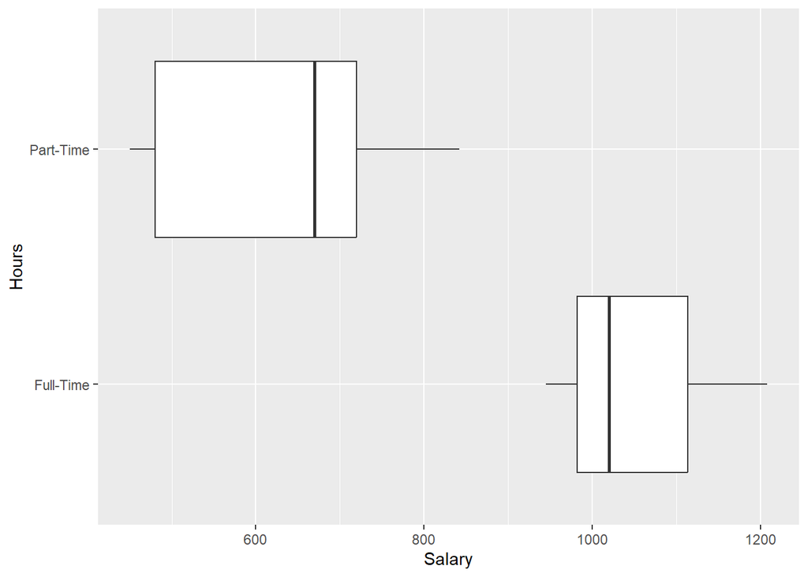

```r
# Testing the function.
viz(df)
```

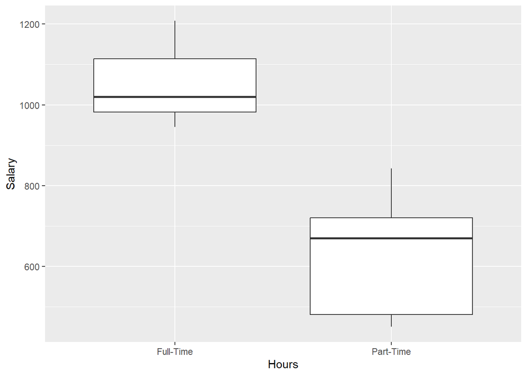

```r
# Switching the order of x and y in the dataframe.
df <- data.frame(
  Hours = c("Part-Time","Full-Time","Part-Time", "Full-Time", "Full-Time","Part-Time","Part-Time","Part-Time"),
  Salary = c(450, 1020, 842, 945, 1208, 670, 480, 720)
)

# Test the function.
viz(df)
```

6. Combine the function in Question 5 and the function in this example ([Link](https://bryantstats.github.io/math421/gganimate/17_writing_functions.html#53)) to have a function that can plot all possible cases (2 categorical, 2 numeric, 1 numeric and 1 categorical).

```r
# Revising the function from the previous question to handle more cases.
viz <- function(d)
{
  if(is.numeric(d[[1]])&(is.numeric(d[[2]])))
  {
    d %>% ggplot(aes(x = d[[1]], y = d[[2]]))+
      geom_point()+
      labs(x = names(d)[1], y = names(d)[2])
  }
  else if (!is.numeric(d[[1]])&!(is.numeric(d[[2]])))
  {
    d %>% ggplot(aes(x = d[[1]], y = d[[2]]))+
      geom_boxplot()+
      labs(x = names(d)[1], y = names(d)[2])
  }
  else if (!is.numeric(d[[1]])&is.numeric(d[[2]]))
  {
    d %>% ggplot(aes(x = d[[1]], y = d[[2]]))+
      geom_col()+
      labs(x = names(d)[1], y = names(d)[2])
  }
  else if (is.numeric(d[[1]])&!(is.numeric(d[[2]])))
  {
    d %>% ggplot(aes(x = d[[1]], y = d[[2]]))+
      geom_col()+
      labs(x = names(d)[1], y = names(d)[2])
  }
  else
    print('This function cannot visualize your data.')
}
```

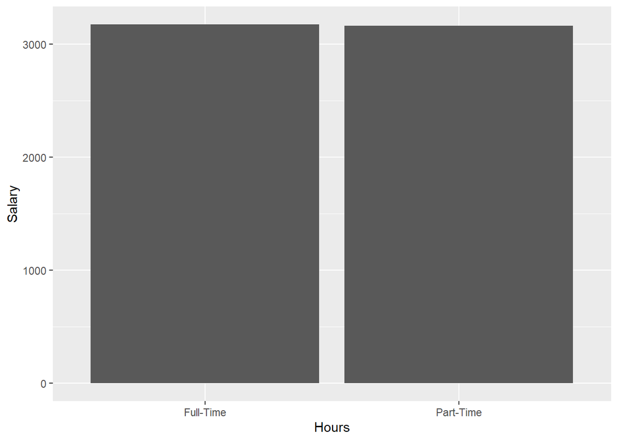

```r
# Testing the function.
viz(df)
```